# R for data science class 1

SANGO Melissa

2026-10-28

## Important definitions in data science

Statistics Modelling Computation Calculus

## Today’s class, we will study

Installation of R Installation of R studio Calculator in R Data importation in R Data description using numerical measures and graphs.

### Data structure (Vectors, Factors, Lists, Data frame, matrix and arrays)

### Vector: The foundational R data structure

### Numeric

Example 1

```r
x<-c(0.5,0.6)
age<-c(20,35,32,29)
summary(age)
```

```
##    Min. 1st Qu.  Median    Mean 3rd Qu.    Max.
##   20.00   26.75   30.50   29.00   32.75   35.00
```

```r
print(x)
```

```
## [1] 0.5 0.6
```

Example 2

```r
age<-c(24,35,16,40)
mean(age)
```

```
## [1] 28.75
```

###Logical

```r
x <- c(TRUE, FALSE)
X <- c(T, F)
```

###Character

```r
x<-c("a","b","c")
class<-c("M","F","F","M")
print(x)
```

```
## [1] "a" "b" "c"
```

###Integer

```r
x<-9:29
print(x)
```

```
##  [1]  9 10 11 12 13 14 15 16 17 18 19 20 21 22 23 24 25 26 27 28 29
```

###Complex

```r
(x<-c(1+0i,2+4i))
```

```
## [1] 1+0i 2+4i
```

###Matrix and operation within matrices

```r
(x<- matrix(1:6,nrow = 2, ncol = 3))
```

```
##      [,1] [,2] [,3]
## [1,]    1    3    5
## [2,]    2    4    6
```

```r
x
```

```
##      [,1] [,2] [,3]
## [1,]    1    3    5
## [2,]    2    4    6
```

```r
(y<-matrix(1:6,nrow = 3,ncol = 2))
```

```
##      [,1] [,2]
## [1,]    1    4
## [2,]    2    5
## [3,]    3    6
```

```r
x%*%y
```

```
##      [,1] [,2]
## [1,]   22   49
## [2,]   28   64
```

###List

```r
(x<-list(1,"a",TRUE, 1+4i))
```

```
## [[1]]
## [1] 1
##
## [[2]]
## [1] "a"
##
## [[3]]
## [1] TRUE
##
## [[4]]
## [1] 1+4i
```

```r
x
```

```
## [[1]]
## [1] 1
##
## [[2]]
## [1] "a"
##
## [[3]]
## [1] TRUE
##
## [[4]]
## [1] 1+4i
```

###Factor

```r
(x<-factor(c("yes","yes","no","yes","no")))
```

```
## [1] yes yes no  yes no
## Levels: no yes
```

### create a vector with NAs in it

```r
x<-c(1,2,NA,10,3)
```

Return a logical vector indicating which elements are NA

```r
is.na(x)
```

```
## [1] FALSE FALSE  TRUE FALSE FALSE
```

```r
x<-c(1,2,4,"NA",5)
bad<-is.na(x)
print(bad)
```

```
## [1] FALSE FALSE FALSE FALSE FALSE
```

```r
x[!bad]
```

```
## [1] "1"  "2"  "4"  "NA" "5"
```

what if there are multiple R objects and you want to take the subset with no missing values in any of those objects?

```r
x<-c(1,3,NA,6,NA,5,7)
y<-c("a","b",NA,"d",NA,"f",NA)
good<-complete.cases(x, y)
good
```

```
## [1]  TRUE  TRUE FALSE  TRUE FALSE  TRUE FALSE
```

###Coercion

if character is present, in a vector, R convert everything in the vector to character strings.

if a vector only contains logical and numbers,R will convert the logical to numbers,Every True become a 1,and every False becomes 0

```r
sum(c(TRUE,TRUE,FALSE,FALSE,FALSE))
```

```
## [1] 2
```

### create data

create data using data frames Data is more general than matrix how?? Because data frame can contains different modes of data(Numeric,character and so on ) Similar to what you can see in SPSS,SAS,…. #let’s create a data frame

```r
studentID<- c(1,2,3,4,5)
gender<-c("F","M","M","F","M")
math_score<-c(18,15,12,9,NA)
it_score<-c(10,13,15,10,16)
scoredata<-data.frame(studentID,gender,math_score,it_score)
scoredata
```

```
##   studentID gender math_score it_score
## 1         1      F         18       10
## 2         2      M         15       13
## 3         3      M         12       15
## 4         4      F          9       10
## 5         5      M         NA       16
```

```r
View(scoredata)
```

### create data from keyboard

steps 1. Create data frame(or matrix) with variable names2. Invoke the text editor in the data objected created at first step

```r
data_class2<-data.frame(height=numeric(0),weight=numeric(0),bmi=numeric(0))
data_class2<-edit(data_class2)
```

##Data Importation R has some features that can allow you to import data from different sources( it can be text file,spreadsheet,or database) 1.Data from excel 2.Data statistical packages(SAS,SPSS,Stata) 3.Data from Text files(ASCII,XML,Webscraping) 4.Data from database management systems(SQL,MySQL,Oracle,Access)

##HW1:Import data from Statistical package and from Database management systems

```r
data_class <- read.table("C:/Users/KABSTORE/Documents/R/class_data.txt", header = TRUE)
variable.names(data_class)
```

```
## [1] "HEIGHT" "WEIGHT"
```

```r
head(data_class)
```

```
##   HEIGHT WEIGHT
## 1    161     50
## 2    155     49
## 3    158     42
## 4    170     65
## 5    160     60
## 6    156     52
```

```r
tail(data_class)
```

```
##    HEIGHT WEIGHT
## 38    169     55
## 39    163     53
## 40    169     60
## 41    167     62
## 42    167     59
## 43    158     49
```

```r
data_class[10:20,]
```

```
##    HEIGHT WEIGHT
## 10    152     46
## 11    167     56
## 12    150     50
## 13    149     40
## 14    156     48
## 15    168     48
## 16    158     50
## 17    152     44
## 18    161     44
## 19    151     43
## 20    158     50
```

```r
summary(data_class$WEIGHT)
```

```
##    Min. 1st Qu.  Median    Mean 3rd Qu.    Max.
##   38.00   45.00   50.00   50.91   58.00   65.00
```

```r
summary(data_class$HEIGHT)
```

```
##    Min. 1st Qu.  Median    Mean 3rd Qu.    Max.
##   146.0   155.5   161.0   160.8   167.0   175.0
```

```r
length(data_class$WEIGHT)
```

```
## [1] 43
```

```r
data_class[,-1]
```

```
##  [1] 50 49 42 65 60 52 59 58 38 46 56 50 40 48 48 50 44 44 43 50 65 49 51 64 38
## [26] 47 38 51 41 63 48 43 59 55 58 40 49 55 53 60 62 59 49
```

```r
data_class$WEIGHT
```

```
##  [1] 50 49 42 65 60 52 59 58 38 46 56 50 40 48 48 50 44 44 43 50 65 49 51 64 38
## [26] 47 38 51 41 63 48 43 59 55 58 40 49 55 53 60 62 59 49
```

In case you want to use data set built in R

```r
data()  #List of datasets currently available
data("airquality")
variable.names(airquality)
```

```
## [1] "Ozone"   "Solar.R" "Wind"    "Temp"    "Month"   "Day"
```

```r
str(airquality)
```

```
## 'data.frame':    153 obs. of  6 variables:
##  $ Ozone  : int  41 36 12 18 NA 28 23 19 8 NA ...
##  $ Solar.R: int  190 118 149 313 NA NA 299 99 19 194 ...
##  $ Wind   : num  7.4 8 12.6 11.5 14.3 14.9 8.6 13.8 20.1 8.6 ...
##  $ Temp   : int  67 72 74 62 56 66 65 59 61 69 ...
##  $ Month  : int  5 5 5 5 5 5 5 5 5 5 ...
##  $ Day    : int  1 2 3 4 5 6 7 8 9 10 ...
```

##Exploration data analysis

###Examine numerical variable using common summary

```r
data_class
```

```
##    HEIGHT WEIGHT
## 1     161     50
## 2     155     49
## 3     158     42
## 4     170     65
## 5     160     60
## 6     156     52
## 7     170     59
## 8     165     58
## 9     154     38
## 10    152     46
## 11    167     56
## 12    150     50
## 13    149     40
## 14    156     48
```

[output cut: 29 more lines]

```r
summary(data_class)
```

```
##      HEIGHT          WEIGHT
##  Min.   :146.0   Min.   :38.00
##  1st Qu.:155.5   1st Qu.:45.00
##  Median :161.0   Median :50.00
##  Mean   :160.8   Mean   :50.91
##  3rd Qu.:167.0   3rd Qu.:58.00
##  Max.   :175.0   Max.   :65.00
```

```r
str(data_class)
```

```
## 'data.frame':    43 obs. of  2 variables:
##  $ HEIGHT: int  161 155 158 170 160 156 170 165 154 152 ...
##  $ WEIGHT: int  50 49 42 65 60 52 59 58 38 46 ...
```

###Summary Statistics

```r
summary(data_class)
```

```
##      HEIGHT          WEIGHT
##  Min.   :146.0   Min.   :38.00
##  1st Qu.:155.5   1st Qu.:45.00
##  Median :161.0   Median :50.00
##  Mean   :160.8   Mean   :50.91
##  3rd Qu.:167.0   3rd Qu.:58.00
##  Max.   :175.0   Max.   :65.00
```

```r
apply(data_class,1,mean)
```

```
##  [1] 105.5 102.0 100.0 117.5 110.0 104.0 114.5 111.5  96.0  99.0 111.5 100.0
## [13]  94.5 102.0 108.0 104.0  98.0 102.5  97.0 104.0 120.0 106.0 109.0 117.5
## [25]  92.0 103.0  94.5 108.0  95.0 115.0 104.0  98.5 111.5 112.0 112.0 101.5
## [37] 104.5 112.0 108.0 114.5 114.5 113.0 103.5
```

```r
apply(data_class,2,mean)
```

```
##    HEIGHT    WEIGHT
## 160.76744  50.90698
```

```r
c(mean(data_class$HEIGHT),sd(data_class$HEIGHT))
```

```
## [1] 160.767442   7.200652
```

```r
c(mean(data_class$WEIGHT),sd(data_class$WEIGHT))
```

```
## [1] 50.906977  7.843147
```

```r
c(Mean=mean(data_class$HEIGHT),SD=sd(data_class$HEIGHT))
```

```
##       Mean         SD
## 160.767442   7.200652
```

```r
c(Mean=mean(data_class$WEIGHT),SD=sd(data_class$WEIGHT))
```

```
##      Mean        SD
## 50.906977  7.843147
```

#Variation and covariation using both numerical and graphs

##Relationship between a categorical and continuous variable

```r
data("iris")
head(iris)
```

```
##   Sepal.Length Sepal.Width Petal.Length Petal.Width Species
## 1          5.1         3.5          1.4         0.2  setosa
## 2          4.9         3.0          1.4         0.2  setosa
## 3          4.7         3.2          1.3         0.2  setosa
## 4          4.6         3.1          1.5         0.2  setosa
## 5          5.0         3.6          1.4         0.2  setosa
## 6          5.4         3.9          1.7         0.4  setosa
```

```r
mean(iris$Petal.Length)
```

```
## [1] 3.758
```

```r
mean(iris$Petal.Length[iris$Species=="setosa"])
```

```
## [1] 1.462
```

```r
mean(iris$Petal.Length[iris$Species=="versicolor"])
```

```
## [1] 4.26
```

```r
mean(iris$Petal.Length[iris$Species=="virginica"])
```

```
## [1] 5.552
```

```r
##shortcut
by(iris$Petal.Length,iris$Species,mean)
```

```
## iris$Species: setosa
## [1] 1.462
## ------------------------------------------------------------
## iris$Species: versicolor
## [1] 4.26
## ------------------------------------------------------------
## iris$Species: virginica
## [1] 5.552
```

```r
by(iris$Petal.Length,iris$Species,sd)
```

```
## iris$Species: setosa
## [1] 0.173664
## ------------------------------------------------------------
## iris$Species: versicolor
## [1] 0.469911
## ------------------------------------------------------------
## iris$Species: virginica
## [1] 0.5518947
```

```r
by(iris$Petal.Length,iris$Species,summary)
```

```
## iris$Species: setosa
##    Min. 1st Qu.  Median    Mean 3rd Qu.    Max.
##   1.000   1.400   1.500   1.462   1.575   1.900
## ------------------------------------------------------------
## iris$Species: versicolor
##    Min. 1st Qu.  Median    Mean 3rd Qu.    Max.
##    3.00    4.00    4.35    4.26    4.60    5.10
## ------------------------------------------------------------
## iris$Species: virginica
##    Min. 1st Qu.  Median    Mean 3rd Qu.    Max.
##   4.500   5.100   5.550   5.552   5.875   6.900
```

###Visualize the differences in continuous variables between categories using Box-and Whisker plot

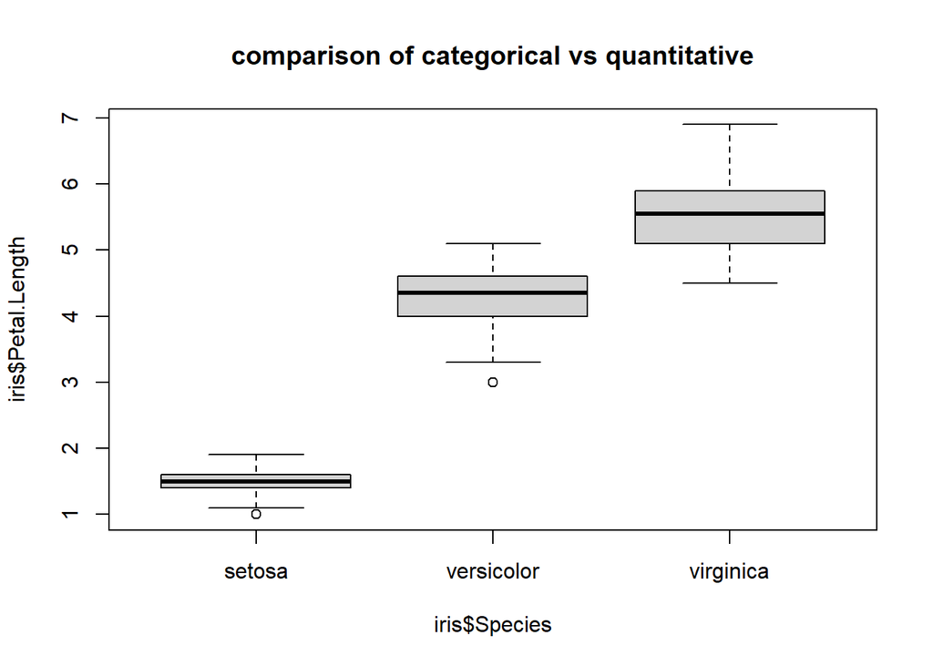

```r
boxplot(iris$Petal.Length~iris$Species,data = iris,main="comparison of categorical vs quantitative")
```

###Relationship between two categorical variables

```r
ucba<-data.frame(UCBAdmissions)
head(ucba)
```

```
##      Admit Gender Dept Freq
## 1 Admitted   Male    A  512
## 2 Rejected   Male    A  313
## 3 Admitted Female    A   89
## 4 Rejected Female    A   19
## 5 Admitted   Male    B  353
## 6 Rejected   Male    B  207
```

```r
cross<-xtabs(Freq~Gender+Admit,data = ucba)
(cross<-xtabs(Freq~Gender+Admit,data = ucba))
```

```
##         Admit
## Gender   Admitted Rejected
##   Male       1198     1493
##   Female      557     1278
```

```r
##Is there gender bias in UCBA graduate admission process
prop.table(cross,1)
```

```
##         Admit
## Gender    Admitted  Rejected
##   Male   0.4451877 0.5548123
##   Female 0.3035422 0.6964578
```

##Simpson’s paradox Phenomenon, where a trend that appears in combined groups of data disappears or reverses when broken down into groups.

```r
cross2<-xtabs(Freq~Gender+Admit,data=ucba[ucba$Dept=="F",])
prop.table(cross2,1)
```

```
##         Admit
## Gender     Admitted   Rejected
##   Male   0.05898123 0.94101877
##   Female 0.07038123 0.92961877
```

##Bar Chart

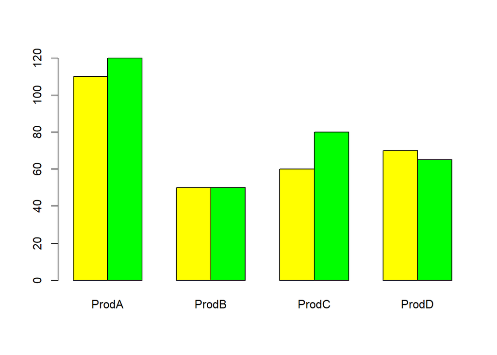

```r
dat<-read.table(text = "ProdA ProdB ProdC ProdD
                1  110 50 60 70
                2  120 50 80 65",header=TRUE)

barplot(as.matrix(dat),beside=TRUE,col=c("Yellow","Green"))
```

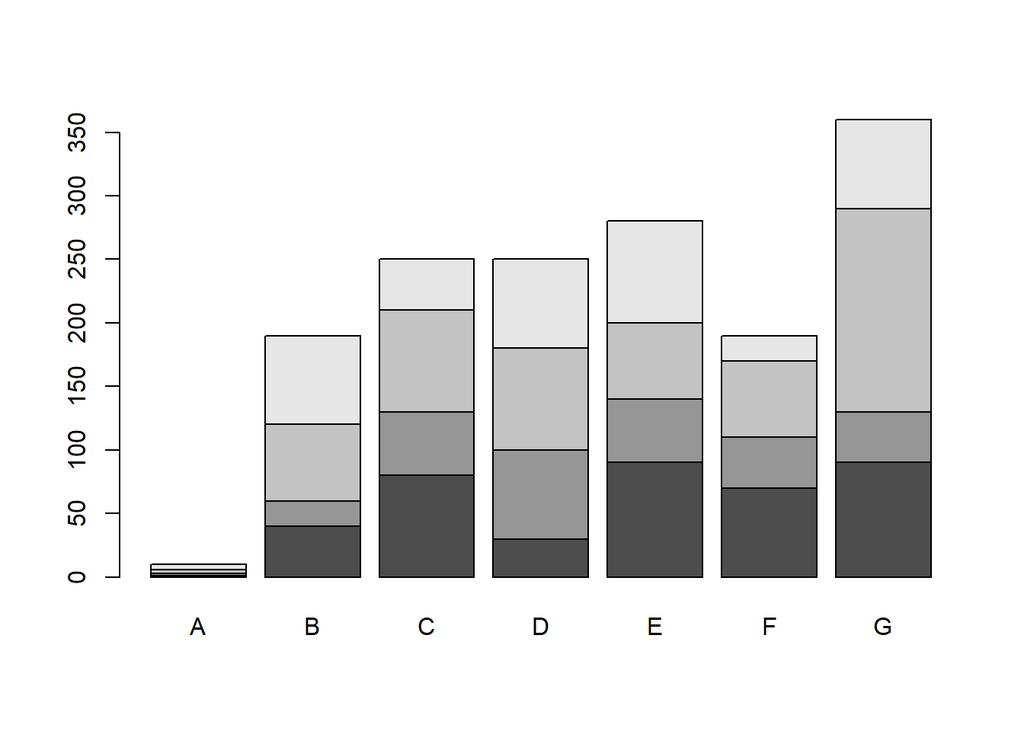

```r
#barplot (as.matrix(dat),beside=TRUE, col=c("gold3","red"))

dat<-read.table(text = "A  B  C  D  E  F  G
1  40  80  30  90  70   90
2  20  50  70  50  40   40
3  60  80  80  60  60  160
4  70  40  70  80  20  70" , header=TRUE)

barplot(as.matrix(dat))
```

### Scatter Plot

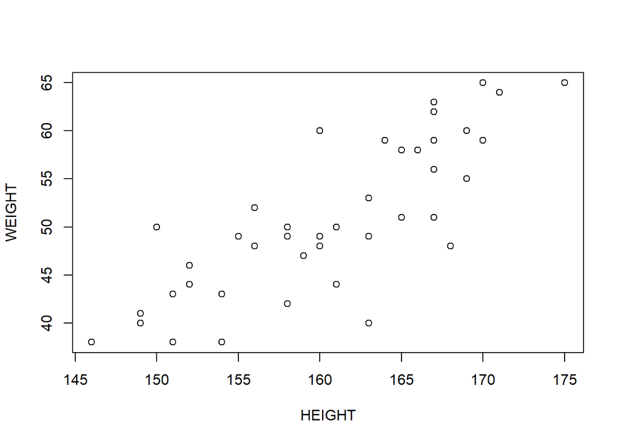

```r
plot(WEIGHT~HEIGHT,data = data_class)
```

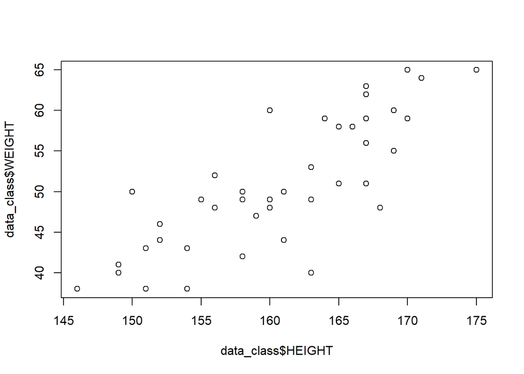

```r
plot(data_class$HEIGHT,data_class$WEIGHT)
```

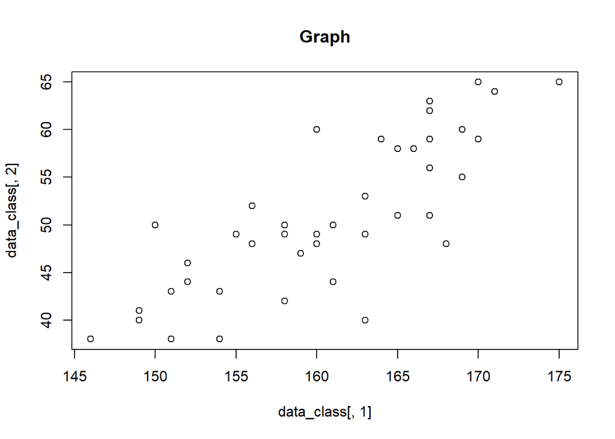

```r
plot(data_class[,1],data_class[,2],main="Graph")
```

```r
cor(data_class$HEIGHT,data_class$WEIGHT)
```

```
## [1] 0.8039983
```

## Linear models

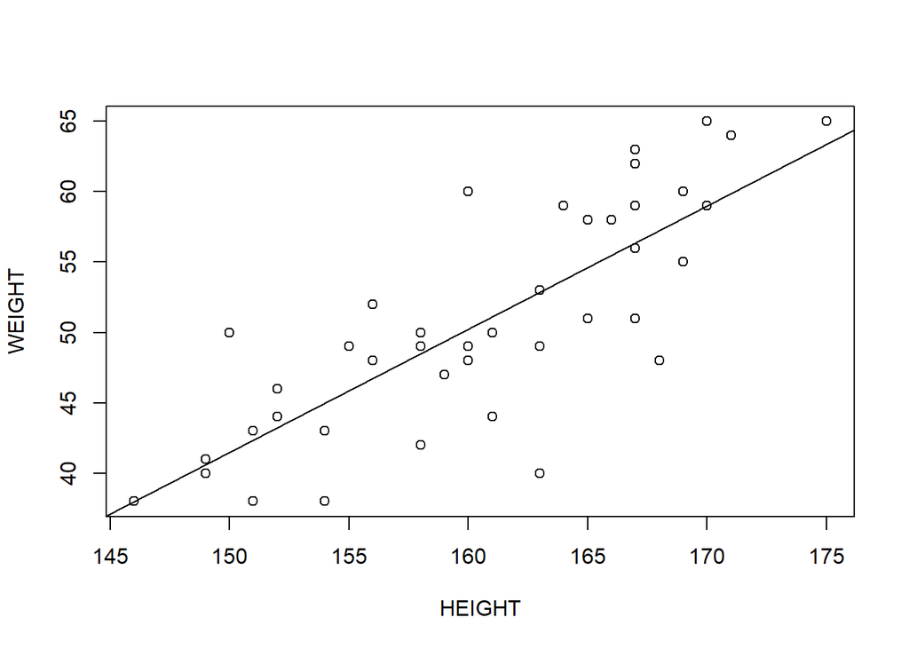

```r
plot(WEIGHT~HEIGHT,data = data_class)
abline(lm(WEIGHT~HEIGHT,data = data_class)$coefficient)
```

```r
data_lm<-lm(HEIGHT~WEIGHT,data = data_class)
summary(data_lm)
```

```
##
## Call:
## lm(formula = HEIGHT ~ WEIGHT, data = data_class)
##
## Residuals:
##      Min       1Q   Median       3Q      Max
## -10.0980  -2.7175  -0.0031   3.0092  10.2834
##
## Coefficients:
##              Estimate Std. Error t value Pr(>|t|)
## (Intercept) 123.19115    4.39028  28.060  < 2e-16 ***
## WEIGHT        0.73814    0.08526   8.658 8.44e-11 ***
## ---
## Signif. codes:  0 '***' 0.001 '**' 0.01 '*' 0.05 '.' 0.1 ' ' 1
##
## Residual standard error: 4.334 on 41 degrees of freedom
## Multiple R-squared:  0.6464, Adjusted R-squared:  0.6378
## F-statistic: 74.95 on 1 and 41 DF,  p-value: 8.442e-11
```

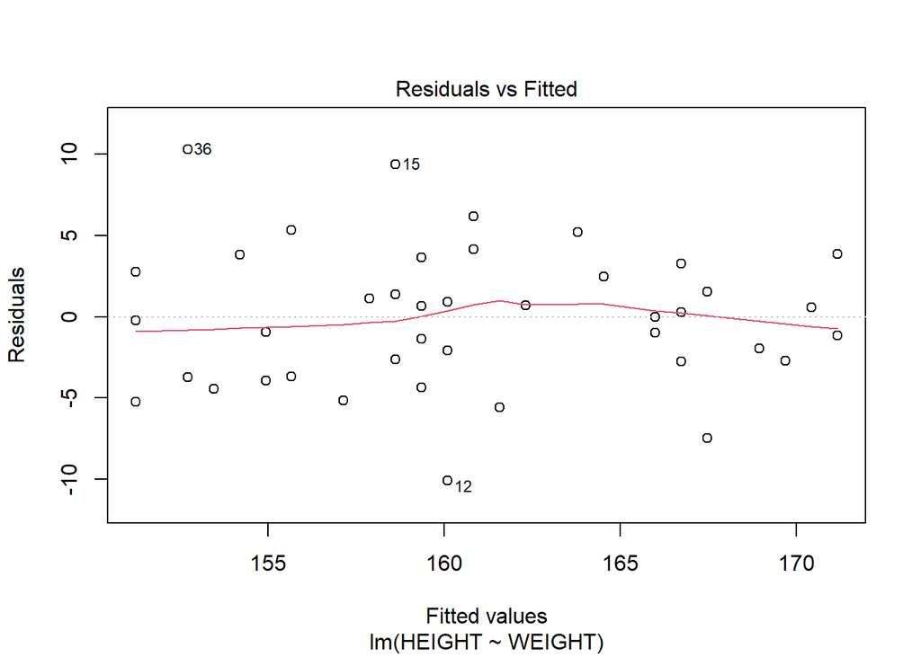

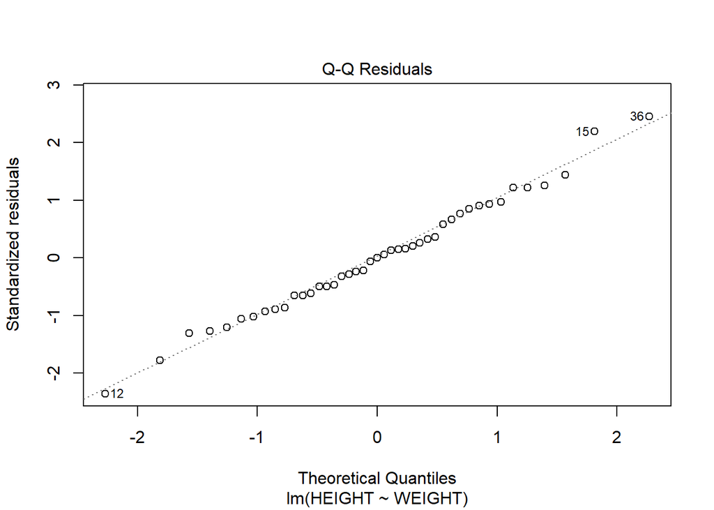

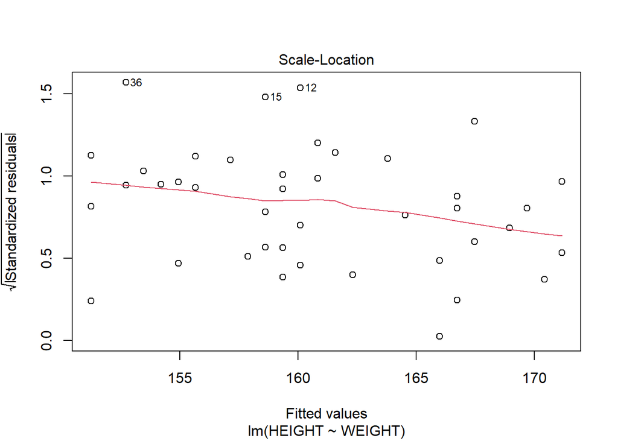

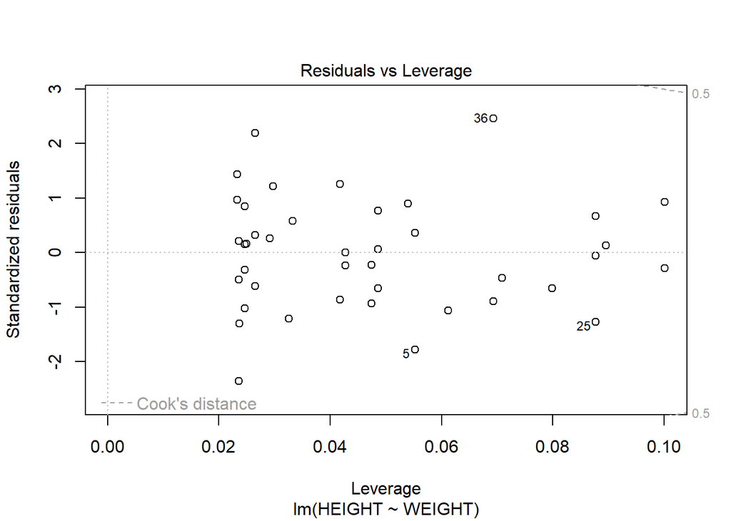

```r
plot(data_lm)
```

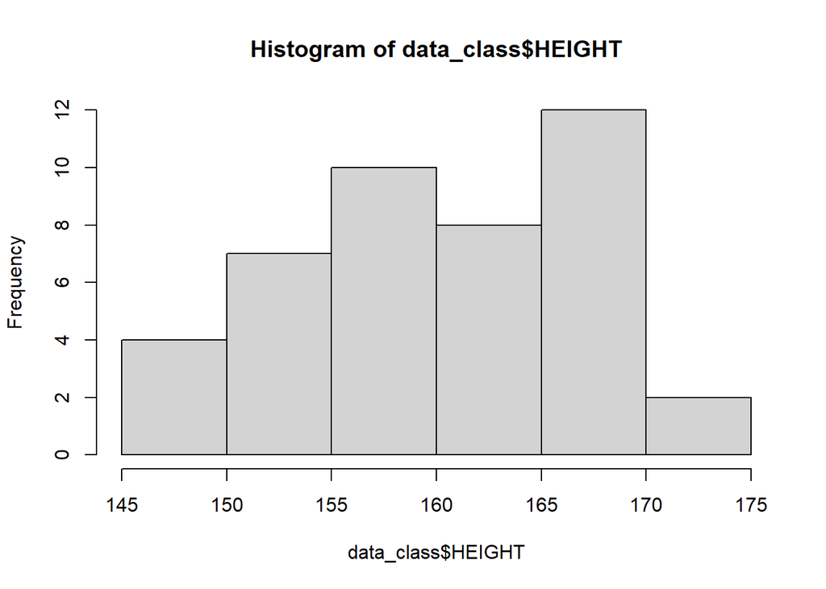

```r
hist(data_class$HEIGHT)
```

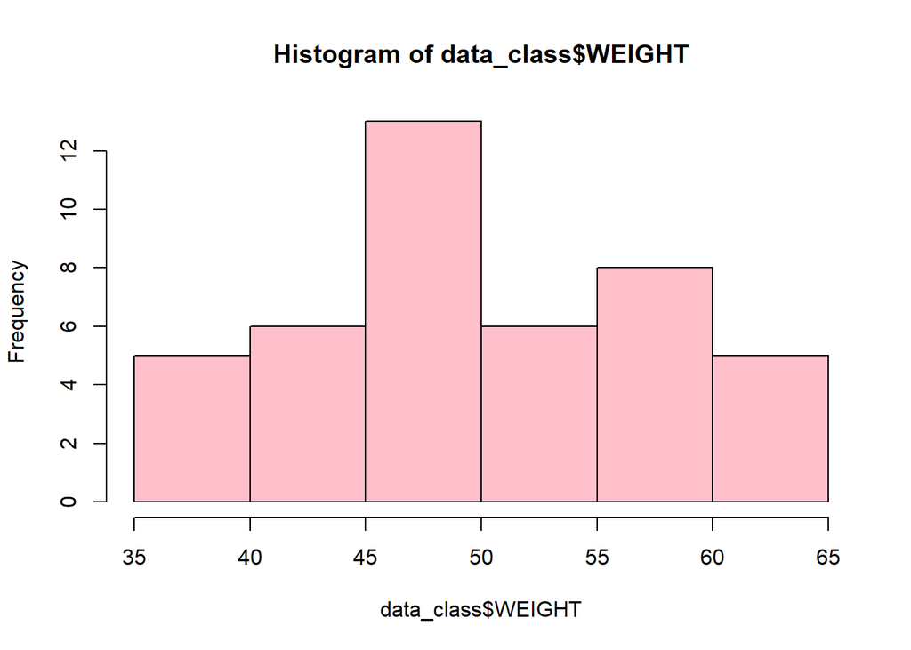

```r
hist(data_class$WEIGHT,col = "pink")
```

##Linear with other line

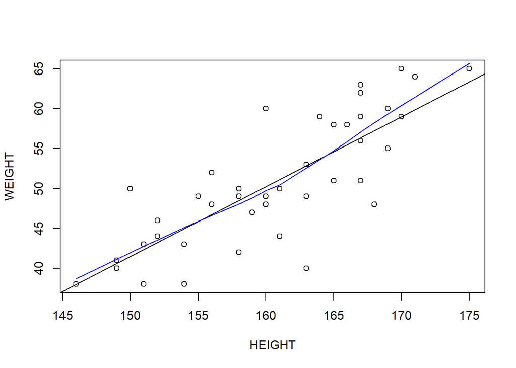

```r
plot(WEIGHT~HEIGHT,data = data_class)
abline(lm(WEIGHT~HEIGHT,data = data_class)$coefficient)
lines(lowess(data_class$HEIGHT,data_class$WEIGHT),col="blue")
```

```r
cor(data_class$HEIGHT,data_class$WEIGHT)
```

```
## [1] 0.8039983
```

```r
lm(WEIGHT~HEIGHT,data_class)
```

```
##
## Call:
## lm(formula = WEIGHT ~ HEIGHT, data = data_class)
##
## Coefficients:
## (Intercept)       HEIGHT
##    -89.8830       0.8757
```

## Data management

### create another variable

```r
attach(data_class)
(BMI<-WEIGHT/(HEIGHT/100)^2)
```

```
##  [1] 19.28938 20.39542 16.82423 22.49135 23.43750 21.36752 20.41522 21.30395
##  [9] 16.02294 19.90997 20.07960 22.22222 18.01721 19.72387 17.00680 20.02884
## [17] 19.04432 16.97465 18.85882 20.02884 21.22449 18.44255 18.28678 21.88708
## [25] 17.82698 18.59104 16.66594 18.73278 18.46764 22.58955 18.75000 18.13122
## [33] 21.93635 19.25703 21.04805 15.05514 19.14062 19.25703 19.94806 21.00767
## [41] 22.23099 21.15529 19.62826
```

```r
(BMI<-round(WEIGHT/(HEIGHT/100)^2,digit=2))
```

```
##  [1] 19.29 20.40 16.82 22.49 23.44 21.37 20.42 21.30 16.02 19.91 20.08 22.22
## [13] 18.02 19.72 17.01 20.03 19.04 16.97 18.86 20.03 21.22 18.44 18.29 21.89
## [25] 17.83 18.59 16.67 18.73 18.47 22.59 18.75 18.13 21.94 19.26 21.05 15.06
## [37] 19.14 19.26 19.95 21.01 22.23 21.16 19.63
```

```r
head(cbind(data_class,BMI),n=5)
```

```
##   HEIGHT WEIGHT   BMI
## 1    161     50 19.29
## 2    155     49 20.40
## 3    158     42 16.82
## 4    170     65 22.49
## 5    160     60 23.44
```

```r
new_data_class<-cbind(data_class,BMI)
tail(cbind(data_class,BMI),n=10)
```

```
##    HEIGHT WEIGHT   BMI
## 34    169     55 19.26
## 35    166     58 21.05
## 36    163     40 15.06
## 37    160     49 19.14
## 38    169     55 19.26
## 39    163     53 19.95
## 40    169     60 21.01
## 41    167     62 22.23
## 42    167     59 21.16
## 43    158     49 19.63
```

##Summary of BMI

```r
summary(BMI)
```

```
##    Min. 1st Qu.  Median    Mean 3rd Qu.    Max.
##   15.06   18.45   19.63   19.60   21.11   23.44
```

```r
stem(BMI,scale = 2)
```

```
##
##   The decimal point is at the |
##
##   15 | 1
##   15 |
##   16 | 0
##   16 | 78
##   17 | 00
##   17 | 8
##   18 | 0134
##   18 | 56789
##   19 | 01333
##   19 | 679
##   20 | 000144
##   20 |
##   21 | 012234
##   21 | 99
##   22 | 22
##   22 | 56
##   23 | 4
```

##Date

```r
today<-Sys.Date()
format(today,format="%B %d %Y")
```

```
## [1] "October 31 2026"
```

```r
format(today,format="%A")
```

```
## [1] "Saturday"
```

```r
today<-Sys.Date()
dob<-as.Date("2001-06-17")

#today<-as.Date("2024-8-25")
difftime(today,dob,units = "days")
```

```
## Time difference of 9267 days
```

```r
startdate <- as.Date("2004-02-13")
enddate   <- as.Date("2011-01-22")
days <- enddate - startdate
days
```

```
## Time difference of 2535 days
```

##Subsetting

###Use of $, []. or [[]] Creation of leadership data interest: how men and women differ in the way they lead their organizations,5 questions were asked in this study. Example of the question: Do men and women in management position differ in the degree to which they defer to superiors? 1: strongly disagree, 2: disagree, 3:neither agree nor disagree,4: agree, 5: strongly agree

```r
manager<-c(1,2,3,4,5)
country<-c("US","UK","US","US","UK")
gender<-c("M","M","F","F","F")
age<-c(26,35,45,39,80)
q1<-c(5,3,2,3,3)
q2<-c(5,2,4,3,5)
q3<-c(2,5,3,5,2)
q4<-c(5,4,5,NA,3)
q5<-c(5,5,3,NA,2)

leadership<-data.frame(manager,country,gender,age,q1,q2,q3,q4,q5,stringsAsFactors = TRUE)
leadership<-data.frame(manager,country,gender,age,q1,q2,q3,q4,q5)
str(leadership)
```

```
## 'data.frame':    5 obs. of  9 variables:
##  $ manager: num  1 2 3 4 5
##  $ country: chr  "US" "UK" "US" "US" ...
##  $ gender : chr  "M" "M" "F" "F" ...
##  $ age    : num  26 35 45 39 80
##  $ q1     : num  5 3 2 3 3
##  $ q2     : num  5 2 4 3 5
##  $ q3     : num  2 5 3 5 2
##  $ q4     : num  5 4 5 NA 3
##  $ q5     : num  5 5 3 NA 2
```

```r
names(leadership)
```

```
## [1] "manager" "country" "gender"  "age"     "q1"      "q2"      "q3"
## [8] "q4"      "q5"
```

What you can do - combine the score of the five questions -handle the missing values - create a dataset of what you want -create age group or age categories - 99 indicate the value is missing ##Missing value

```r
leadership$age[leadership$age==80]<-NA
head(leadership)
```

```
##   manager country gender age q1 q2 q3 q4 q5
## 1       1      US      M  26  5  5  2  5  5
## 2       2      UK      M  35  3  2  5  4  5
## 3       3      US      F  45  2  4  3  5  3
## 4       4      US      F  39  3  3  5 NA NA
## 5       5      UK      F  NA  3  5  2  3  2
```

```r
leadership$agecat[leadership$age>75]<-"Elder"
leadership$agecat[leadership$age>=35 & leadership$age<=75]<-"Middle Aged"
leadership$agecat[leadership$age<35]<-"Young"
```

###One way to handle missing value Deleting all observations with missing data ( Listwise deletion) is one of the several methods of handling incomplete datasets. Note: You can also replacing the missing value by the average of the remaining data.

```r
is.na(leadership[,5:9])
```

```
##         q1    q2    q3    q4    q5
## [1,] FALSE FALSE FALSE FALSE FALSE
## [2,] FALSE FALSE FALSE FALSE FALSE
## [3,] FALSE FALSE FALSE FALSE FALSE
## [4,] FALSE FALSE FALSE  TRUE  TRUE
## [5,] FALSE FALSE FALSE FALSE FALSE
```

```r
newdata<-na.omit(leadership)
newdata
```

```
##   manager country gender age q1 q2 q3 q4 q5      agecat
## 1       1      US      M  26  5  5  2  5  5       Young
## 2       2      UK      M  35  3  2  5  4  5 Middle Aged
## 3       3      US      F  45  2  4  3  5  3 Middle Aged
```

##Sorting data

```r
order(leadership$age)
```

```
## [1] 1 2 4 3 5
```

```r
newdata2<-leadership[order(leadership$age),]
```

##Merging data sets To merge two data frame horizontally, you use merge() function. In most cases, two data frames are joined by one or more common key variables. -example 1: merge(dataframeA, dataframeB,by=“ID”) -example 2: merge(dataframeA,dataframeB, by=c(“ID”,“country”))

the second merge the two dataframes by ID and country

To join two data frame( datasets) vertically, use rbind() function: Note that the two data set must have the same variables

###Subset (selecting variables,dropping variables,selecting observation )

```r
newdata3<-leadership[,c(5:9)]
myvars<-c("q1","q2","q3","q4","q5")
(newdata3<-leadership[myvars])
```

```
##   q1 q2 q3 q4 q5
## 1  5  5  2  5  5
## 2  3  2  5  4  5
## 3  2  4  3  5  3
## 4  3  3  5 NA NA
## 5  3  5  2  3  2
```

```r
newdata4<-leadership[,c(-1,-2)]
(newdata4<-leadership[,-(1:5)])
```

```
##   q2 q3 q4 q5      agecat
## 1  5  2  5  5       Young
## 2  2  5  4  5 Middle Aged
## 3  4  3  5  3 Middle Aged
## 4  3  5 NA NA Middle Aged
## 5  5  2  3  2        <NA>
```

```r
newdata5<-leadership[,c(-1,-7)]
leadership[[4]]
```

```
## [1] 26 35 45 39 NA
```

```r
leadership$age
```

```
## [1] 26 35 45 39 NA
```

```r
newdata6<-leadership[c(-1,-3),]
newdata6<-leadership[c(2,4,5),]
newdata7<-subset(leadership,age>=35|age<24,select=c(q1,q2,q3,q4,q5))
```

```r
attach(leadership)
#newdata7<-leadership[gender="M" & age>30,]
(newdata7<-leadership[gender=="M" & age>30,])
```

```
##   manager country gender age q1 q2 q3 q4 q5      agecat
## 2       2      UK      M  35  3  2  5  4  5 Middle Aged
```

```r
(newdata7<-leadership[gender=="F" & age>30,])
```

[output not shown]

```r
detach(leadership)
```